# Regional Regression

Worked example 8.1

# 1 Introduction

This worked example demonstrates the application of regional regression analysis to model low flows in a spatial context. We use a data set of 30 catchments situated in the forelands and prealps in the north-east of Austria (Zone 1). The data set is fully described in Laaha & Blöschl (2006a, 2006b).

The target variable is the long-term low flow characteristic $Q95$ (flow quantile, that is exceeded 95% of the time) , standardized by catchment area to eliminate its predominant effect on low flows. For nested catchments, the $Q95$ was dis-aggregated into the residual $Q95$ of sub-catchments, assuming regional synchronicity of low flow events.

In this section we learn how to

- fit a multiple linear regression model,
- perform stepwise regression to deal with collinearity,
- employ the Cook’s distance method to deal with outliers,
- use robust regression methods and
- create specific plots to analyse the quality of the regression model and the specific contribution of each predictor to the regression estimate.

# 2 Data import

The text file named `zone1_30_ENG.txt` contains several catchment descriptors for the 30 catchments of the regional data set mentioned above. Each observation (each line) in the text file corresponds to a single gauging station located at the catchment outlet. The variables (our catchment descriptors) are represented as columns of this data set.

Let us import this tabular data set into an object `x0`. As the vary first line of the text file contains the column headers, we have to specify the `header` argument accordingly. The function `read.table()` will return a `data.frame`.

```r
x0 <- read.table("../../../hd-book/chapter8/Regression/zone1_30_ENG.txt", header = TRUE)
```

To get a glimpse of the imported data set, let us print the first three lines of the object `x0`. They contain the catchment descriptors of the first three catchments.

```r
head(x0, n = 3)
```

```
##    DBMSNR  HZBNR   X_LB   Y_LB Q95s Q95w  Q95     A   H0   Hx   Hr    Hm
## 1 1001003 210039 632579 399019 1.11 1.76 1.21 11.75 3.36 8.50 5.14 5.885
## 2 1001005 210054 641191 397501 1.09 1.55 1.23 10.76 2.37 7.05 4.68 3.604
## 3 1001006 210062 639309 404781 0.92 1.25 0.98 14.96 2.56 7.81 5.25 4.701
##    Sm  Ssl  Smo Sst     P    Ps    Pw Gb   Gq   Gt Gf Gl   Gc Ggs  Ggd Gso
## 1 8.3 60.5 39.5   0 7.371 4.874 2.496  0  5.8 20.4  0  0 65.9   0  7.9   0
## 2 4.8 91.5  8.6   0 6.690 4.405 2.284  0  7.8 58.5  0  0 14.9   0 18.9   0
## 3 7.4 64.6 35.4   0 7.012 4.568 2.443  0 10.7 33.6  0  0 47.2   0  8.5   0
##    Lu   La Lc  Lg   Lf Lr Lwa    D
## 1 0.5 43.9  0 8.4 47.2  0   0 8.81
## 2 3.4 38.2  0 2.4 56.1  0   0 7.20
## 3 4.3 38.3  0 9.3 48.1  0   0 8.39
```

To make sure all variables are imported either as class `integer` or `numeric` (and not accidentally as class `character` or `factor`) let us have a look at the structure of the object `x0`. Calling the function `str()` will print the dimensions of the `data.frame` in the very first line. The following lines contain the name of the variable, the class of the variable and the first few values.

```r
str(x0)
```

```
## 'data.frame':    30 obs. of  36 variables:
##  $ DBMSNR: int  1001003 1001005 1001006 1001008 1001019 1001021 1001022 1..
##  $ HZBNR : int  210039 210054 210062 210088 210211 210237 210245 210252 2..
##  $ X_LB  : int  632579 641191 639309 637884 613036 631684 623122 630727 6..
##  $ Y_LB  : int  399019 397501 404781 437789 350694 371673 383547 374437 3..
##  $ Q95s  : num  1.11 1.09 0.92 0.67 2.33 1.26 1.63 0.72 0.57 0.46 ...
##  $ Q95w  : num  1.76 1.55 1.25 0.91 2.88 2 2.19 1.21 0.91 0.71 ...
##  $ Q95   : num  1.21 1.23 0.98 0.71 2.76 1.44 1.83 1.06 0.65 0.63 ...
##  $ A     : num  11.8 10.8 15 22.3 13.9 ...
##  $ H0    : num  3.36 2.37 2.56 1.75 2.37 2.41 3.28 2.64 2.2 2.01 ...
##  $ Hx    : num  8.5 7.05 7.81 7.2 4.52 7.76 8.34 8.27 4.46 3.34 ...
##  $ Hr    : num  5.14 4.68 5.25 5.45 2.15 5.35 5.06 5.63 2.26 1.33 ...
##  $ Hm    : num  5.88 3.6 4.7 3.21 3.1 ...
##  $ Sm    : num  8.3 4.8 7.4 5.9 3.9 5 10.4 5.6 4.6 3.8 ...
##  $ Ssl   : num  60.5 91.5 64.6 75.9 92.3 86.4 40.4 80.9 92.6 94.1 ...
```

[output cut: 22 more lines]

Another way to find out the dimensions of an object is to call `dim(x0)`, `ncol(x0)` or `nrow(x0)` explicitly.

The raw data set `x0` contains some variables which we do not want to use in our regression model, e.g. the id number or the coordinates of the gauging station. We will remove the columns to simplify the subsequent analysis. It is also a good idea to assign meaningful row names to the `data.frame` (e.g. the station id `'HZBNR'`) to be able to identify the observations later on.

```r
rownames(x0) <- x0$HZBNR

remove <- c("DBMSNR", "HZBNR", "X_LB", "Y_LB", "Q95s", "Q95w", "A")
keep <- setdiff(colnames(x0), remove)
x <- x0[, keep]
head(x)
```

```
##         Q95   H0   Hx   Hr      Hm  Sm  Ssl  Smo Sst       P      Ps
## 210039 1.21 3.36 8.50 5.14 5.88500 8.3 60.5 39.5   0 7.37100 4.87400
## 210054 1.23 2.37 7.05 4.68 3.60400 4.8 91.5  8.6   0 6.69000 4.40500
## 210062 0.98 2.56 7.81 5.25 4.70100 7.4 64.6 35.4   0 7.01200 4.56800
## 210088 0.71 1.75 7.20 5.45 3.21219 5.9 75.9 24.1   0 6.30441 4.03484
## 210211 2.76 2.37 4.52 2.15 3.10100 3.9 92.3  7.7   0 6.83000 4.57900
## 210237 1.44 2.41 7.76 5.35 3.78307 5.0 86.4 13.6   0 6.80122 4.59959
##             Pw Gb   Gq   Gt  Gf  Gl   Gc  Ggs  Ggd Gso  Lu   La  Lc  Lg
## 210039 2.49600  0  5.8 20.4 0.0 0.0 65.9  0.0  7.9   0 0.5 43.9 0.0 8.4
## 210054 2.28400  0  7.8 58.5 0.0 0.0 14.9  0.0 18.9   0 3.4 38.2 0.0 2.4
## 210062 2.44300  0 10.7 33.6 0.0 0.0 47.2  0.0  8.5   0 4.3 38.3 0.0 9.3
## 210088 2.26722  0 20.5 63.1 0.0 1.2 13.4  1.5  0.2   0 7.8 56.4 1.8 2.6
## 210211 2.25200  0  5.7 46.3 0.0 0.0  0.0 48.0  0.0   0 0.0 58.8 0.0 0.4
## 210237 2.20211  0  7.2 55.2 1.8 2.9  8.0 14.4 10.6   0 0.7 54.0 0.0 5.9
##          Lf  Lr Lwa    D
## 210039 47.2 0.0   0 8.81
## 210054 56.1 0.0   0 7.20
## 210062 48.1 0.0   0 8.39
## 210088 31.2 0.2   0 6.27
## 210211 40.8 0.0   0 9.15
## 210237 39.4 0.0   0 8.58
```

# 3 Simple linear regression

```r
lm.simple <- lm(Q95 ~ P, data = x)

summary(lm.simple)
```

```
##
## Call:
## lm(formula = Q95 ~ P, data = x)
##
## Residuals:
##     Min      1Q  Median      3Q     Max
## -1.5445 -0.5422 -0.2251  0.0541  3.0542
##
## Coefficients:
##             Estimate Std. Error t value Pr(>|t|)
## (Intercept)  -2.0631     1.1309  -1.824  0.07878 .
## P             0.5289     0.1727   3.062  0.00482 **
## ---
## Signif. codes:  0 '***' 0.001 '**' 0.01 '*' 0.05 '.' 0.1 ' ' 1
##
## Residual standard error: 0.96 on 28 degrees of freedom
## Multiple R-squared:  0.2508, Adjusted R-squared:  0.2241
## F-statistic: 9.375 on 1 and 28 DF,  p-value: 0.004817
```

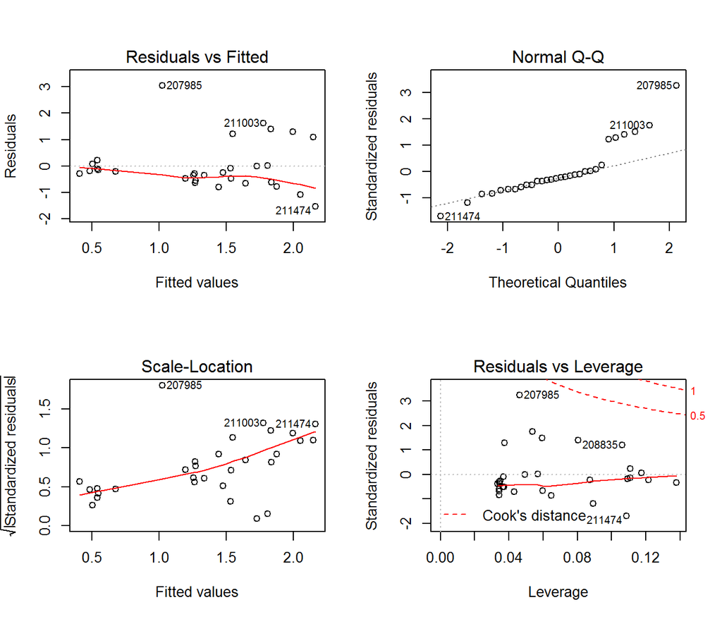

```r
par(mfrow = c(2, 2))
plot(lm.simple)
```

# 4 Stepwise regression

In stepwise regression an ‘optimal’ model (based on the Akaike Information Criterion, $AIC$) is obtained by iteratively adding or removing variables.

## 4.1 Manual backward selection

When starting from the full model (all variables are used as predictors) the function `drop1()` can be used to remove the least significant variable. If the resulting model is considered better if its $AIC$ is lower than the original model. This procedure is called *backward selection*.

```r
model.full <- lm(Q95 ~ ., data = x)
```

The model is specified by a so called *formula*. It has to parts, a left-hand side (LHS) and a right-hand side (RHS), separated by a tilde sign ‘~’. The LHS contains just the name of the variable we want to predict with our model, in our its the $Q95$. On the RHS we have to list all variables that should be used as predictors in the model. There is no need of mentioning all variables explicitly. In this context the dot (‘.’) means *all columns of the data argument not otherwise used in the formula*. Hence `Q95 ~ .` is equivalent to

```
## Q95 ~ H0 + Hx + Hr + Hm + Sm + Ssl + Smo + Sst + P + Ps + Pw +
##     Gb + Gq + Gt + Gf + Gl + Gc + Ggs + Ggd + Gso + Lu + La +
##     Lc + Lg + Lf + Lr + Lwa + D
```

```r
drop1(model.full)
```

```
## Single term deletions
##
## Model:
## Q95 ~ H0 + Hx + Hr + Hm + Sm + Ssl + Smo + Sst + P + Ps + Pw +
##     Gb + Gq + Gt + Gf + Gl + Gc + Ggs + Ggd + Gso + Lu + La +
##     Lc + Lg + Lf + Lr + Lwa + D
##        Df Sum of Sq     RSS     AIC
## <none>              0.16767 -99.608
## H0      0   0.00000 0.16767 -99.608
## Hx      0   0.00000 0.16767 -99.608
## Hr      0   0.00000 0.16767 -99.608
## Hm      1   0.79387 0.96154 -49.213
## Sm      1   0.13697 0.30464 -83.695
## Ssl     1   1.73711 1.90479 -28.705
## Smo     1   1.71512 1.88279 -29.053
## Sst     1   1.82226 1.98993 -27.393
## P       1   2.87480 3.04247 -14.656
## Ps      1   2.85967 3.02735 -14.805
## Pw      1   2.88700 3.05467 -14.536
## Gb      1   0.32174 0.48941 -69.473
## Gq      1   0.32871 0.49638 -69.048
## Gt      1   0.33509 0.50276 -68.665
## Gf      1   0.32061 0.48828 -69.542
## Gl      1   0.32313 0.49081 -69.387
## Gc      1   0.31392 0.48159 -69.956
## Ggs     1   0.32868 0.49635 -69.050
## Ggd     1   0.33267 0.50034 -68.810
## Gso     1   0.46748 0.63515 -61.653
## Lu      1   1.55687 1.72454 -31.687
## La      1   1.54920 1.71687 -31.821
## Lc      1   1.53949 1.70716 -31.991
## Lg      1   1.53973 1.70740 -31.987
## Lf      1   1.54583 1.71351 -31.880
## Lr      1   1.68005 1.84772 -29.617
## Lwa     1   1.38167 1.54934 -34.901
## D       1   0.57139 0.73906 -57.107
```

The above table tells us that among all single term deletions (removing only one variable) the model without $Pw$ would have the worst (=highest) sum of squared residuals (RSS) value of `3.1` and therefore also the worst (=highest) the AIC of `-14.54`.

## 4.2 Manual forward selection

Another approach is to start from the empty model and adding the variable with highest explicative value by applying the function `add1()`. This is called *forward selection*. When using the function `drop1()`, there was no need to explicitly define the scope of the variables to drop because for `drop1()` a missing scope is taken to be all terms in the model. That is not the case for its counterpart `add1()`; here we have to set the scope explicitly.

```r
model.init <- lm(Q95 ~ P, data = x)
scope <- formula(paste("~", paste(colnames(x)[-1], collapse = " + ")))
add1(model.init, scope = scope)
```

```
## Single term additions
##
## Model:
## Q95 ~ P
##        Df Sum of Sq    RSS     AIC
## <none>              25.804 -0.5204
## H0      1    0.0723 25.731  1.3954
## Hx      1    2.5418 23.262 -1.6315
## Hr      1    2.2560 23.548 -1.2651
## Hm      1    1.6324 24.171 -0.4810
## Sm      1    0.7097 25.094  0.6429
## Ssl     1    0.1427 25.661  1.3132
## Smo     1    0.1105 25.693  1.3509
## Sst     1    3.0734 22.730 -2.3251
## Ps      1    2.0601 23.744 -1.0166
## Pw      1    2.0292 23.774 -0.9775
## Gb      1    0.8388 24.965  0.4882
## Gq      1    3.4904 22.313 -2.8804
## Gt      1    1.8171 23.987 -0.7111
## Gf      1    0.0693 25.734  1.3989
## Gl      1    0.1086 25.695  1.3530
## Gc      1    0.3474 25.456  1.0729
## Ggs     1    2.9767 22.827 -2.1977
## Ggd     1    0.3058 25.498  1.1219
## Gso     1    0.0048 25.799  1.4740
## Lu      1    1.2721 24.532 -0.0371
## La      1    0.1356 25.668  1.3215
## Lc      1    0.1649 25.639  1.2873
## Lg      1    1.9892 23.814 -0.9272
## Lf      1    0.0083 25.795  1.4700
## Lr      1    0.3691 25.434  1.0473
## Lwa     1    6.4173 19.386 -7.0989
## D       1    2.5644 23.239 -1.6606
```

Again, this table tells us that among all other variables choosing the variable $Lwa$ would minimize the sum of squared residuals (RSS) to a value of `19.4` and the AIC to `-7.1`.

## 4.3 Automated variable selection

The process described above can be repeated unless any removal or addition of a variable would result in an increase of the $AIC$ and therefore in an inferior model.

```r
lm.forward <- step(model.init, scope = scope, direction = "forward", trace = 0)
summary(lm.forward)
```

```
##
## Call:
## lm(formula = Q95 ~ P + Lwa + Ggs + Sm + Gc, data = x)
##
## Residuals:
##     Min      1Q  Median      3Q     Max
## -1.2495 -0.4340 -0.0783  0.3460  1.4258
##
## Coefficients:
##              Estimate Std. Error t value Pr(>|t|)
## (Intercept) -0.483431   0.971478  -0.498 0.623278
## P            0.024337   0.197203   0.123 0.902811
## Lwa          2.636955   0.599260   4.400 0.000191 ***
## Ggs          0.045853   0.011522   3.980 0.000555 ***
## Sm           0.139203   0.070460   1.976 0.059804 .
## Gc           0.015194   0.008104   1.875 0.073020 .
## ---
## Signif. codes:  0 '***' 0.001 '**' 0.01 '*' 0.05 '.' 0.1 ' ' 1
##
## Residual standard error: 0.6757 on 24 degrees of freedom
## Multiple R-squared:  0.6819, Adjusted R-squared:  0.6156
## F-statistic: 10.29 on 5 and 24 DF,  p-value: 2.315e-05
```

It is also possible to obtain an ANOVA-like F-test of predictor significance (i.e. sequential ANOVA) by calling the `anova()` method on the object return by `step()`.

```r
anova(lm.forward)
```

```
## Analysis of Variance Table
##
## Response: Q95
##           Df  Sum Sq Mean Sq F value    Pr(>F)
## P          1  8.6401  8.6401 18.9239 0.0002168 ***
## Lwa        1  6.4173  6.4173 14.0556 0.0009908 ***
## Ggs        1  3.9512  3.9512  8.6540 0.0071235 **
## Sm         1  2.8725  2.8725  6.2915 0.0192948 *
## Gc         1  1.6050  1.6050  3.5154 0.0730204 .
## Residuals 24 10.9576  0.4566
## ---
## Signif. codes:  0 '***' 0.001 '**' 0.01 '*' 0.05 '.' 0.1 ' ' 1
```

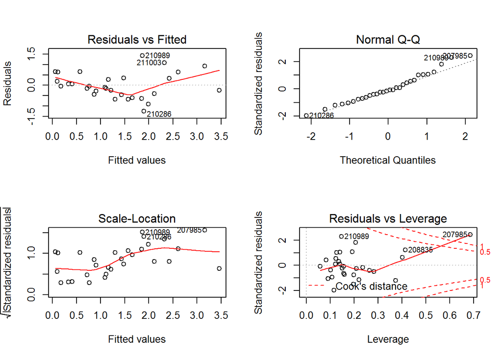

```r
par(mfrow = c(2, 2))
plot(lm.forward)
```

```r
lm.backward <- step(model.full, scope = scope, direction = "backward", trace = 0)
summary(lm.backward)
```

```
##
## Call:
## lm(formula = Q95 ~ Hx + Hm + Sm + Ssl + Smo + Sst + P + Ps +
##     Pw + Gb + Gq + Gt + Gf + Gl + Gc + Ggs + Ggd + Gso + Lu +
##     La + Lc + Lg + Lf + Lr + Lwa + D, data = x)
##
## Residuals:
##     210039     210054     210062     210088     210211     210237
## -1.174e-01 -1.045e-01  1.117e-01 -1.445e-02 -5.307e-02  2.204e-01
##     210245     210252     210286     210294     210310     207985
##  6.034e-02 -8.800e-02  4.495e-02 -1.521e-02 -6.194e-03 -2.047e-02
##     207993     208041     208058     208108     208447     208512
## -2.291e-02 -7.054e-02  3.848e-02 -1.974e-03 -3.792e-02  1.050e-01
##     208579     208611     208637     208678     208835     209189
## -5.465e-02 -6.402e-03  1.820e-02  4.476e-02  7.256e-03 -1.735e-17
##     210989     211003     211037     211045     211474     211508
##  1.348e-02  3.561e-02 -8.372e-02  1.445e-02 -1.342e-01  1.169e-01
##
## Coefficients:
##               Estimate Std. Error t value Pr(>|t|)
## (Intercept) -3051.8700   338.6467  -9.012  0.00288 **
## Hx              0.2164     0.1627   1.330  0.27567
## Hm             -3.7193     0.7415  -5.016  0.01526 *
## Sm             -0.7712     0.2611  -2.954  0.05983 .
## Ssl            15.1994     2.2879   6.644  0.00695 **
## Smo            15.3395     2.2969   6.678  0.00685 **
## Sst            14.0889     2.1397   6.584  0.00713 **
## P           -1633.2697   227.0659  -7.193  0.00554 **
## Ps           1635.0521   227.7885   7.178  0.00557 **
## Pw           1632.9136   226.6201   7.206  0.00551 **
## Gb             -4.7413     1.7827  -2.660  0.07637 .
## Gq             -4.8532     1.7935  -2.706  0.07341 .
## Gt             -4.8623     1.7916  -2.714  0.07292 .
## Gf             -4.7432     1.7795  -2.665  0.07599 .
## Gl             -4.7433     1.7816  -2.662  0.07618 .
## Gc             -4.7031     1.7828  -2.638  0.07779 .
## Ggs            -4.8412     1.7956  -2.696  0.07403 .
## Ggd            -4.8539     1.7876  -2.715  0.07283 .
## Gso            -5.5529     1.7780  -3.123  0.05235 .
## Lu             19.8618     3.5384   5.613  0.01118 *
## La             20.2940     3.5888   5.655  0.01095 *
## Lc             20.2583     3.5930   5.638  0.01104 *
## Lg             20.3434     3.6032   5.646  0.01100 *
## Lf             20.2727     3.5880   5.650  0.01097 *
## Lr             35.4022     6.0954   5.808  0.01016 *
## Lwa            20.7714     3.1676   6.558  0.00721 **
## D              -0.5637     0.1740  -3.239  0.04789 *
## ---
## Signif. codes:  0 '***' 0.001 '**' 0.01 '*' 0.05 '.' 0.1 ' ' 1
##
## Residual standard error: 0.2367 on 3 degrees of freedom
## Multiple R-squared:  0.9951, Adjusted R-squared:  0.9528
## F-statistic: 23.53 on 26 and 3 DF,  p-value: 0.01194
```

```r
lm.both <- step(model.init, scope = scope, direction = "both", trace = 0)
summary(lm.both)
```

```
##
## Call:
## lm(formula = Q95 ~ Lwa + Ggs + Sm + Gc, data = x)
##
## Residuals:
##      Min       1Q   Median       3Q      Max
## -1.23854 -0.43772 -0.09556  0.34741  1.43576
##
## Coefficients:
##              Estimate Std. Error t value Pr(>|t|)
## (Intercept) -0.371534   0.341822  -1.087 0.287439
## Lwa          2.640617   0.586619   4.501 0.000136 ***
## Ggs          0.046486   0.010115   4.596 0.000106 ***
## Sm           0.144978   0.051626   2.808 0.009524 **
## Gc           0.015409   0.007758   1.986 0.058088 .
## ---
## Signif. codes:  0 '***' 0.001 '**' 0.01 '*' 0.05 '.' 0.1 ' ' 1
##
## Residual standard error: 0.6623 on 25 degrees of freedom
## Multiple R-squared:  0.6817, Adjusted R-squared:  0.6307
## F-statistic: 13.38 on 4 and 25 DF,  p-value: 5.817e-06
```

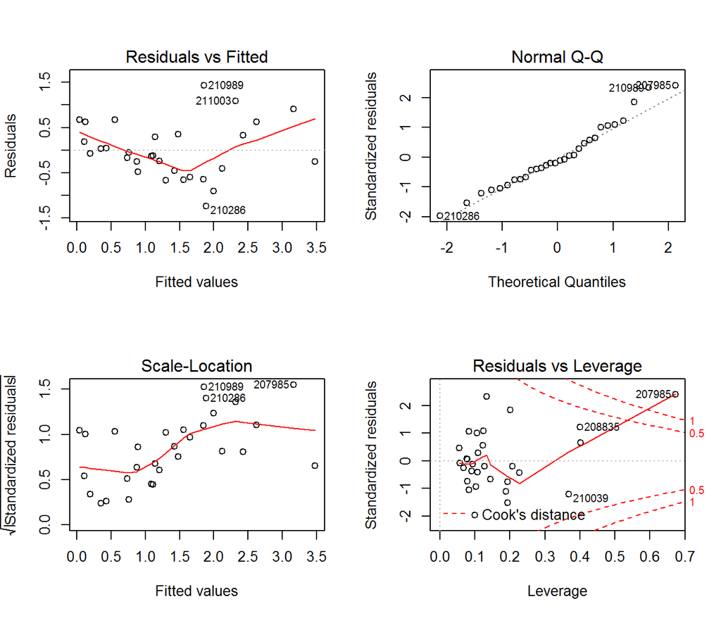

```r
par(mfrow = c(2,2))
plot(lm.both)
```

## 4.4 Plotting the results

One can show the model performance in a scatter plot by printing the predicted values of the Q95 floe against the actual, observed values of the Q95.

Macht man in der Regel nicht, oder? Eher resid vs. obs.

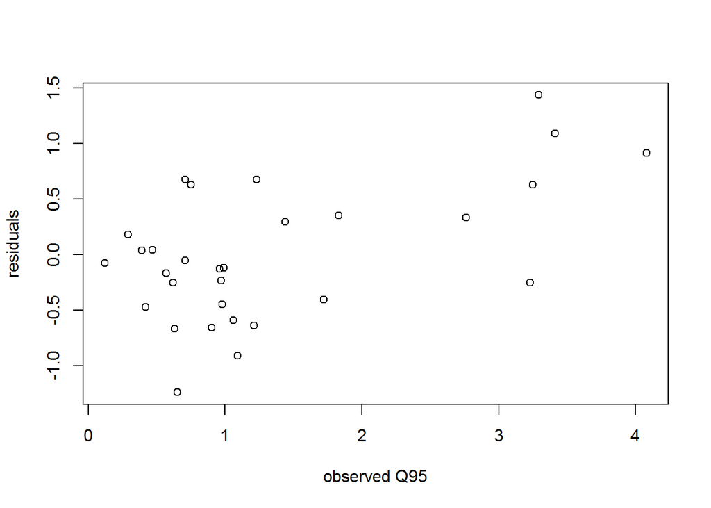

```r
plot(x = x$Q95, y = resid(lm.both), xlab = "observed Q95", ylab = "residuals")
```

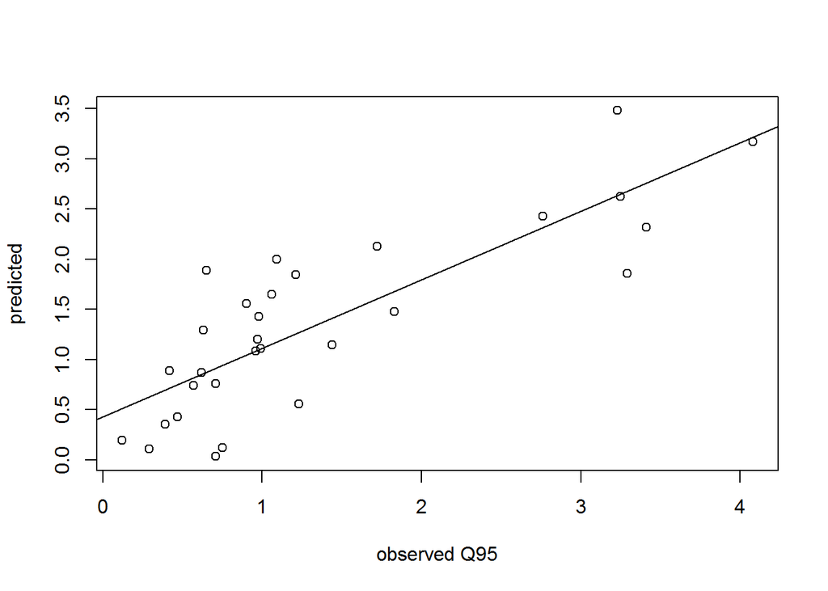

```r
plot(x = x$Q95, y = fitted(lm.both), xlab = "observed Q95", ylab = "predicted")
abline(lsfit(lm.both$model$Q95, lm.both$fitted.values))
```

To depict the contribution of each predictor $x_j$ used in the model to the estimated $y$ the function `termplot()` plots each regression term ($\beta_j \cdot x_j$) against its predictor.

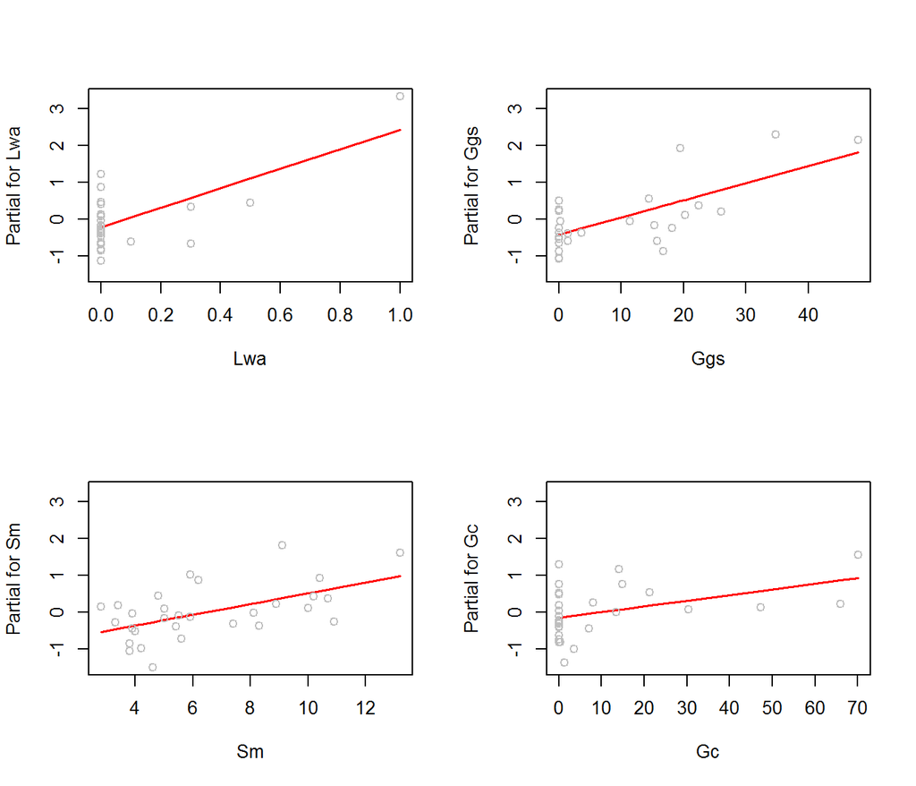

```r
par(mfrow = c(2,2))
termplot(lm.both, partial.resid = TRUE)
```

# 5 Remove outliers based on Cook’s distance

In the diagnostic plot of the final model obtained by stepwise regression the station with id number `207985` popped out because of its high Cook’s distance of `2.39`.

The analysis is conducted in 3 steps (that may be repeated until no outliers remain…)

1. Detect outliers based on Cook’s distance. You can do this either by looking a the diagnostic plot or by subsetting the result of the function `cooks.distance()`. Let’s for example eliminate all outliers with an absolute Cook’s distance larger than 1.

```r
pos <- which(abs(cooks.distance(lm.both)) >= 1)
pos
```

```
## 207985
##     12
```

In our data set this is the station with the id number `207985`, which is observation number (row number) `12`.

2. Now we can eliminate the outliers manually, by removing this row.

```r
x1 <- x[-pos, ]
dim(x1)
```

```
## [1] 29 29
```

3. Finally we have to re-run our stepwise regression model.

```r
lm.new <- step(lm(Q95 ~ P, data = x1), scope = scope, trace = 0)
summary(lm.new)
```

```
##
## Call:
## lm(formula = Q95 ~ Ggs + Gc + Sm + H0, data = x1)
##
## Residuals:
##      Min       1Q   Median       3Q      Max
## -0.98559 -0.44049  0.03207  0.20995  1.33798
##
## Coefficients:
##              Estimate Std. Error t value Pr(>|t|)
## (Intercept) -0.779134   0.413641  -1.884  0.07179 .
## Ggs          0.051168   0.008710   5.875 4.64e-06 ***
## Gc           0.015331   0.006568   2.334  0.02829 *
## Sm           0.126060   0.043808   2.878  0.00829 **
## H0           0.215529   0.113354   1.901  0.06932 .
## ---
## Signif. codes:  0 '***' 0.001 '**' 0.01 '*' 0.05 '.' 0.1 ' ' 1
##
## Residual standard error: 0.5597 on 24 degrees of freedom
## Multiple R-squared:  0.7192, Adjusted R-squared:  0.6724
## F-statistic: 15.37 on 4 and 24 DF,  p-value: 2.31e-06
```

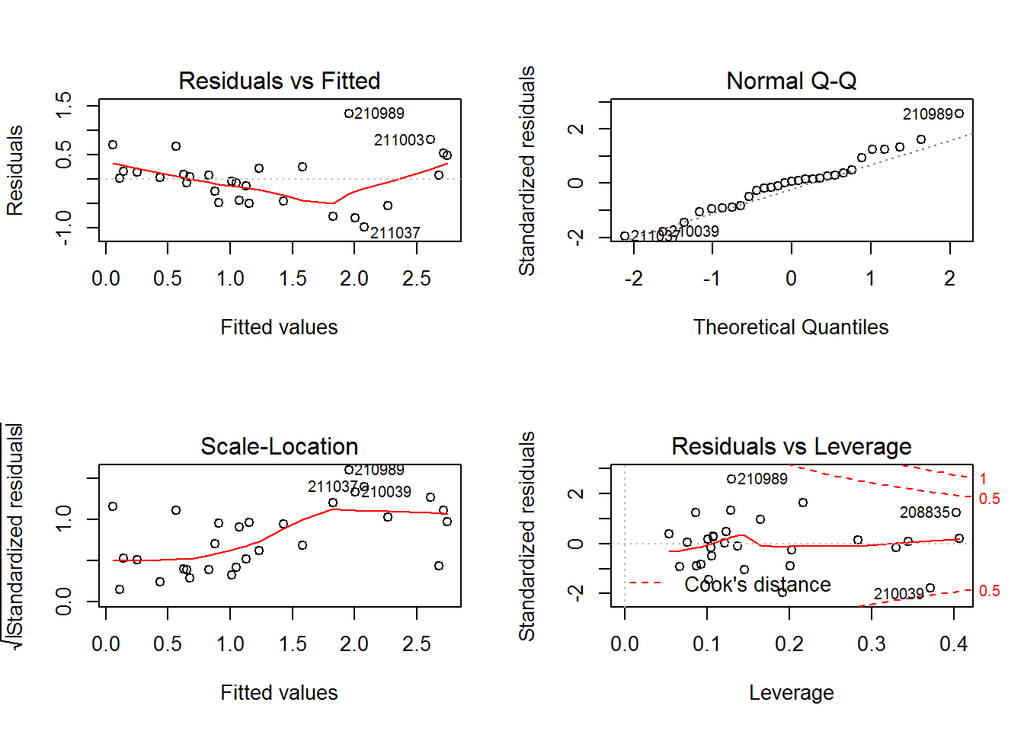

```r
par(mfrow = c(2,2))
plot(lm.new)
```

# 6 Robust regression (alternative to manual outlier detection)

```r
library(robustbase)
set.seed(3141) # to set seed for random number generator
model <- Q95 ~ Ggs + Gc + Sm + H0
x.lts <- ltsReg(formula = model, data = x, alpha = 0.9)
summary(x.lts)
```

```
##
## Call:
## ltsReg.formula(formula = model, data = x, alpha = 0.9)
##
## Residuals (from reweighted LS):
##        Min         1Q     Median         3Q        Max
## -0.9121246 -0.0786171  0.0005475  0.1846441  0.8139449
##
## Coefficients:
##            Estimate Std. Error t value Pr(>|t|)
## Intercept -0.552932   0.324788  -1.702 0.102763
## Ggs        0.047584   0.006807   6.991 5.13e-07 ***
## Gc         0.028605   0.006346   4.507 0.000175 ***
## Sm         0.069754   0.036465   1.913 0.068866 .
## H0         0.226059   0.087970   2.570 0.017477 *
## ---
## Signif. codes:  0 '***' 0.001 '**' 0.01 '*' 0.05 '.' 0.1 ' ' 1
##
## Residual standard error: 0.4334 on 22 degrees of freedom
## Multiple R-Squared: 0.8165,  Adjusted R-squared: 0.7831
## F-statistic: 24.47 on 4 and 22 DF,  p-value: 7.929e-08
```

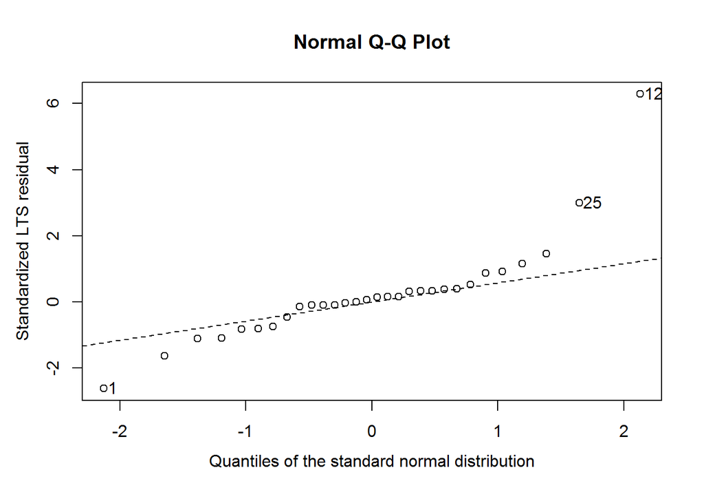

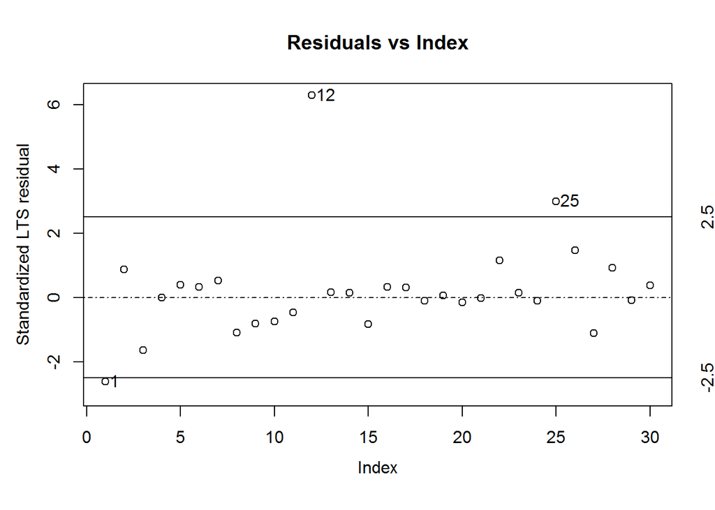

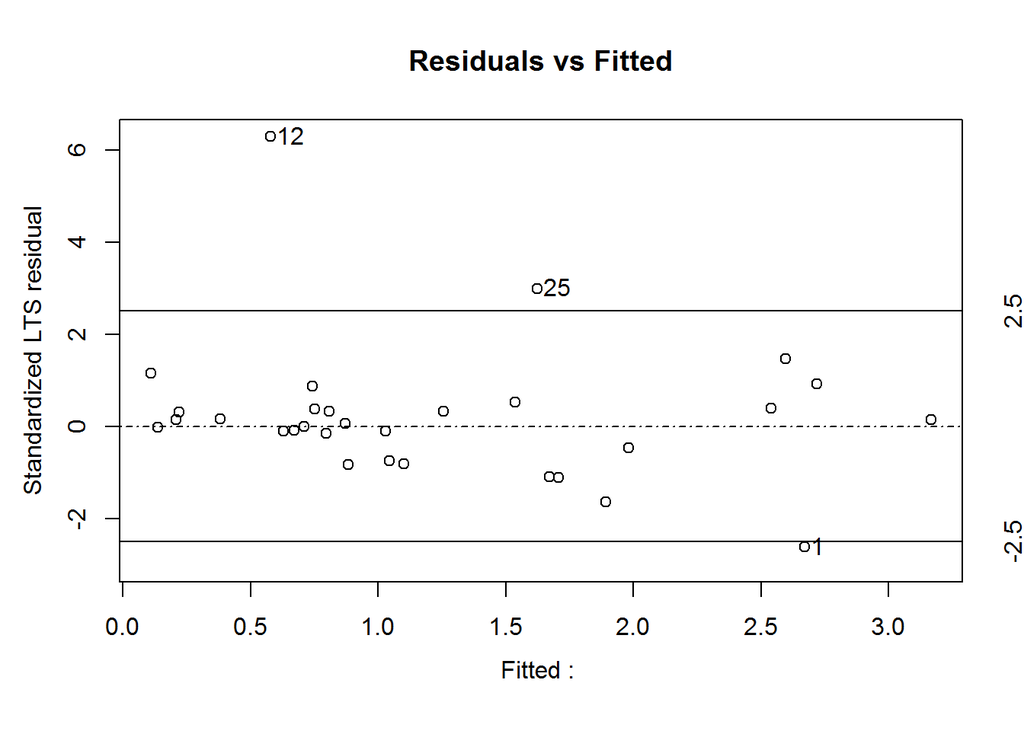

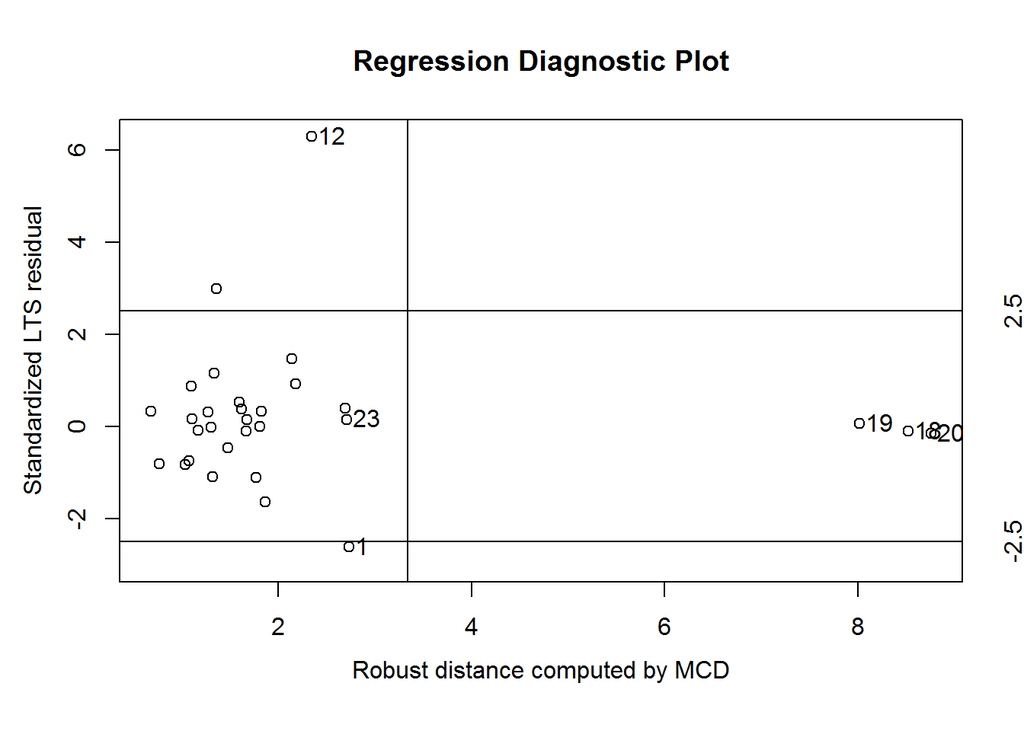

```r
plot(x.lts)
```

```r
x.rob <- lmrob(formula = model, data = x)
summary(x.rob)
```

```
##
## Call:
## lmrob(formula = model, data = x)
##  \--> method = "MM"
## Residuals:
##       Min        1Q    Median        3Q       Max
## -1.776957 -0.195700  0.002921  0.230256  3.497841
##
## Coefficients:
##             Estimate Std. Error t value Pr(>|t|)
## (Intercept) -0.41284    0.35266  -1.171  0.25279
## Ggs          0.04416    0.01516   2.913  0.00744 **
## Gc           0.03379    0.01107   3.053  0.00531 **
## Sm           0.05860    0.03709   1.580  0.12668
## H0           0.20443    0.05530   3.697  0.00107 **
## ---
## Signif. codes:  0 '***' 0.001 '**' 0.01 '*' 0.05 '.' 0.1 ' ' 1
##
## Robust residual standard error: 0.3287
## Multiple R-squared:  0.8415, Adjusted R-squared:  0.8161
## Convergence in 30 IRWLS iterations
##
## Robustness weights:
##  3 observations c(1,12,25) are outliers with |weight| = 0 ( < 0.0033);
##  2 weights are ~= 1. The remaining 25 ones are summarized as
##    Min. 1st Qu.  Median    Mean 3rd Qu.    Max.
##  0.1881  0.8252  0.9559  0.8734  0.9916  0.9987
## Algorithmic parameters:
##        tuning.chi                bb        tuning.psi        refine.tol
##         1.548e+00         5.000e-01         4.685e+00         1.000e-07
##           rel.tol         scale.tol         solve.tol       eps.outlier
##         1.000e-07         1.000e-10         1.000e-07         3.333e-03
##             eps.x warn.limit.reject warn.limit.meanrw
##         1.275e-10         5.000e-01         5.000e-01
##      nResample         max.it       best.r.s       k.fast.s          k.max
##            500             50              2              1            200
##    maxit.scale      trace.lev            mts     compute.rd fast.s.large.n
##            200              0           1000              0           2000
##                   psi           subsampling                   cov
##            "bisquare"         "nonsingular"         ".vcov.avar1"
## compute.outlier.stats
##                  "SM"
## seed : int(0)
```

```
## recomputing robust Mahalanobis distances
```

```
## saving the robust distances 'MD' as part of 'x.rob'
```

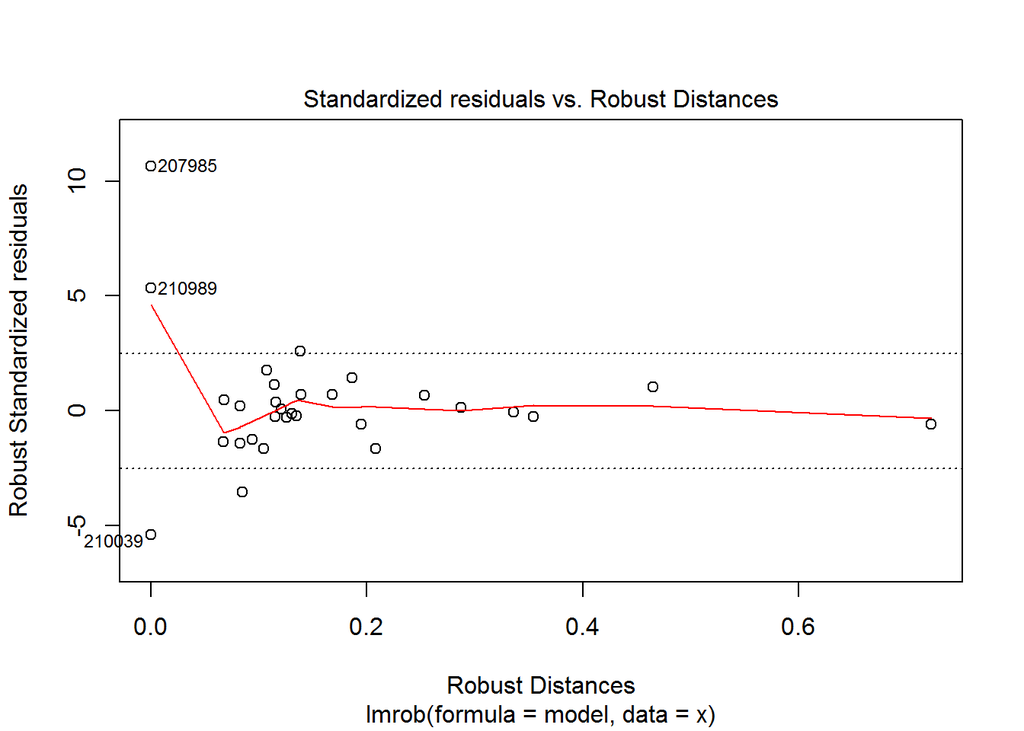

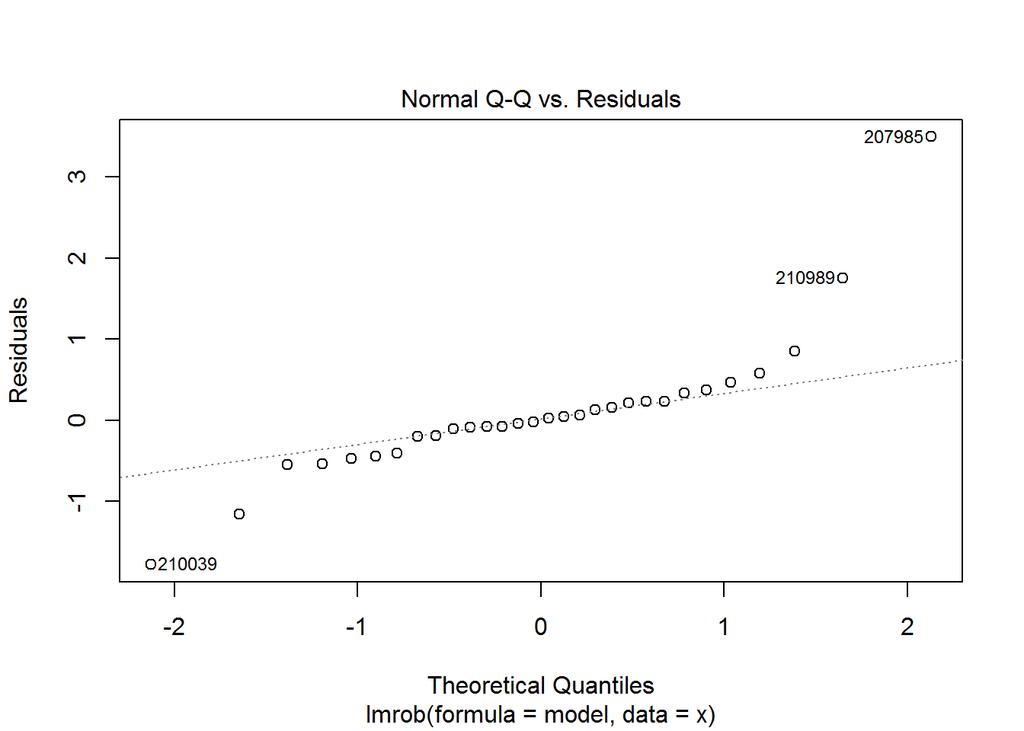

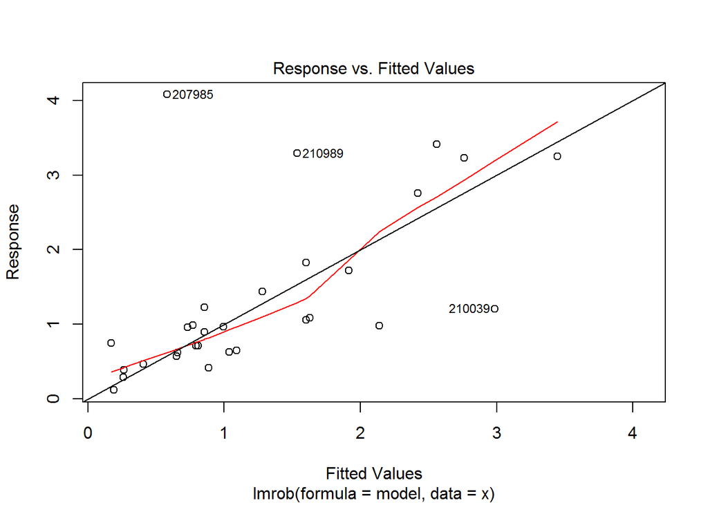

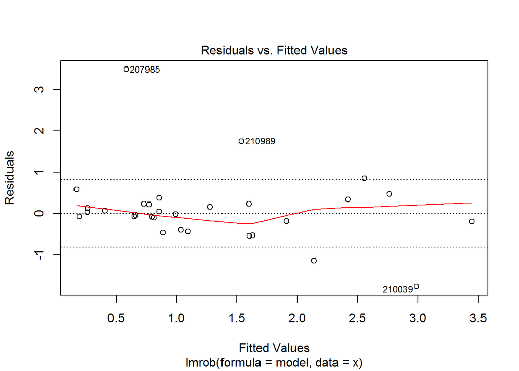

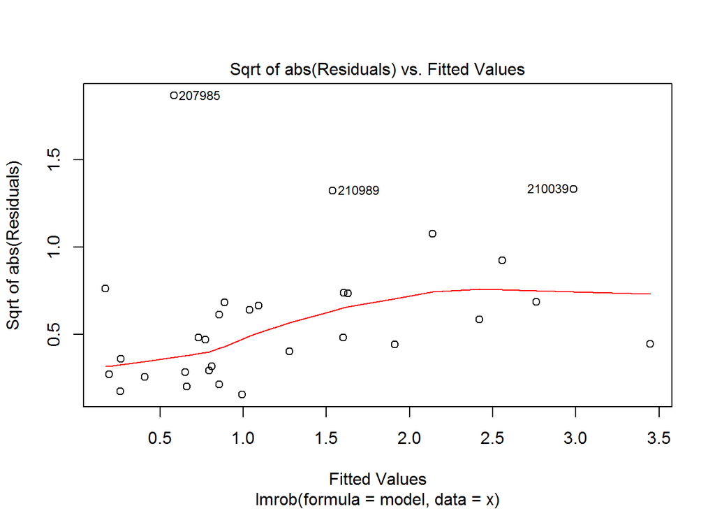

```r
plot(x.rob)
```

# 7 References

- Laaha, G. & Blöschl, G. (2006a) Seasonality indices for regionalizing low flows. Hydrol. Process. 20(18), 3851-3878. doi:10.1002/hyp.6161
- Laaha, G. & Blöschl, G. (2006b) A comparison of low flow regionalisation methods-catchment grouping. J. Hydrol. 323(1-4), 193-214. doi:10.1016/j.jhydrol.2005.09.001